# STA137 Project

2023-12-02

## Data Preprocessing

```r
library(lubridate)
library(dplyr)
library(tidyr)
library(xts)
```

```r
library(ggplot2)
library(ggpmisc)
library(ggthemes)
library(zoo)
library(tseries)
library(tidyverse)
library(skimr)
library(GGally)
library(viridis)
library(tibbletime)
#setwd("/Users/janiceli/Desktop")
avocado = read.csv("avocado.csv")
```

```r
# Change the category variable into factor
avocado$type = as.factor(avocado$type)
avocado$region = as.factor(avocado$region)
# Convert 'Date' to a Date object
avocado$Date <- as.Date(avocado$Date)
```

```r
# Check the NA value
any(is.na(avocado))
```

```
## [1] FALSE
```

```r
# There is no NA values.
```

```r
str(avocado)
```

```
## 'data.frame':    18249 obs. of  14 variables:
##  $ X           : int  0 1 2 3 4 5 6 7 8 9 ...
##  $ Date        : Date, format: "2015-12-27" "2015-12-20" ...
##  $ AveragePrice: num  1.33 1.35 0.93 1.08 1.28 1.26 0.99 0.98 1.02 1.07 ...
##  $ Total.Volume: num  64237 54877 118220 78992 51040 ...
##  $ X4046       : num  1037 674 795 1132 941 ...
##  $ X4225       : num  54455 44639 109150 71976 43838 ...
##  $ X4770       : num  48.2 58.3 130.5 72.6 75.8 ...
##  $ Total.Bags  : num  8697 9506 8145 5811 6184 ...
##  $ Small.Bags  : num  8604 9408 8042 5677 5986 ...
##  $ Large.Bags  : num  93.2 97.5 103.1 133.8 197.7 ...
##  $ XLarge.Bags : num  0 0 0 0 0 0 0 0 0 0 ...
##  $ type        : Factor w/ 2 levels "conventional",..: 1 1 1 1 1 1 1 1 1 1 ...
##  $ year        : int  2015 2015 2015 2015 2015 2015 2015 2015 2015 2015 ...
##  $ region      : Factor w/ 54 levels "Albany","Atlanta",..: 1 1 1 1 1 1 1 1 1 1 ...
```

```r
summary(avocado)
```

```
##        X              Date             AveragePrice    Total.Volume
##  Min.   : 0.00   Min.   :2015-01-04   Min.   :0.440   Min.   :      85
##  1st Qu.:10.00   1st Qu.:2015-10-25   1st Qu.:1.100   1st Qu.:   10839
##  Median :24.00   Median :2016-08-14   Median :1.370   Median :  107377
##  Mean   :24.23   Mean   :2016-08-13   Mean   :1.406   Mean   :  850644
##  3rd Qu.:38.00   3rd Qu.:2017-06-04   3rd Qu.:1.660   3rd Qu.:  432962
##  Max.   :52.00   Max.   :2018-03-25   Max.   :3.250   Max.   :62505647
##
##      X4046              X4225              X4770           Total.Bags
##  Min.   :       0   Min.   :       0   Min.   :      0   Min.   :       0
##  1st Qu.:     854   1st Qu.:    3009   1st Qu.:      0   1st Qu.:    5089
##  Median :    8645   Median :   29061   Median :    185   Median :   39744
##  Mean   :  293008   Mean   :  295155   Mean   :  22840   Mean   :  239639
##  3rd Qu.:  111020   3rd Qu.:  150207   3rd Qu.:   6243   3rd Qu.:  110783
##  Max.   :22743616   Max.   :20470573   Max.   :2546439   Max.   :19373134
##
##    Small.Bags         Large.Bags       XLarge.Bags                 type
##  Min.   :       0   Min.   :      0   Min.   :     0.0   conventional:9126
##  1st Qu.:    2849   1st Qu.:    127   1st Qu.:     0.0   organic     :9123
##  Median :   26363   Median :   2648   Median :     0.0
##  Mean   :  182195   Mean   :  54338   Mean   :  3106.4
##  3rd Qu.:   83338   3rd Qu.:  22029   3rd Qu.:   132.5
##  Max.   :13384587   Max.   :5719097   Max.   :551693.7
##
##       year                      region
##  Min.   :2015   Albany             :  338
##  1st Qu.:2015   Atlanta            :  338
##  Median :2016   BaltimoreWashington:  338
##  Mean   :2016   Boise              :  338
##  3rd Qu.:2017   Boston             :  338
##  Max.   :2018   BuffaloRochester   :  338
##                 (Other)            :16221
```

## Data Analysis

- Initial data transformations: Check if it is necessary to stabilize the variance of the data or if transformations to symmetry are necessary. Then start modeling with the classical decomposition of a time series into trend plus seasonality plus stationary errors.

```r
levels(avocado$type)
```

```
## [1] "conventional" "organic"
```

```r
org <- avocado %>% select(Date, AveragePrice, type, Total.Volume) %>% filter(type == "organic")
con <- avocado %>% select(Date, AveragePrice, type, Total.Volume) %>% filter(type == "conventional")
```

```r
con_month <- con %>%
  mutate(Date = as.Date(paste(Date, "-01"), format="%Y-%m-%d")) %>%
  group_by(Date) %>%
  summarize(AveragePrice = mean(AveragePrice))

org_month <- org %>%
  mutate(Date = as.Date(paste(Date, "-01"), format="%Y-%m-%d")) %>%
  group_by(Date) %>%
  summarize(AveragePrice = mean(AveragePrice))
```

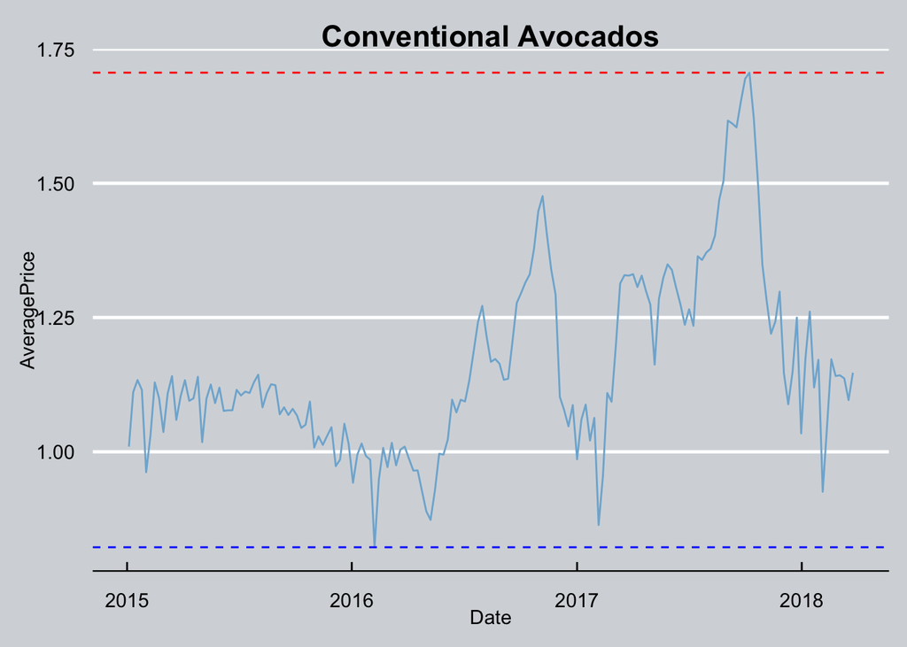

```r
con_monthly <- ggplot(con_month, aes(x = Date, y = AveragePrice)) +
  geom_line(color = "#7FB3D5") +
  theme_economist() +
  theme(
    plot.title = element_text(hjust = 0.5),
    plot.background = element_rect(fill = "#D5D8DC")
  ) +
  labs(title = "Conventional Avocados") +
  geom_hline(yintercept = max(con_month$AveragePrice), linetype = "dashed", color = "red") +
  geom_hline(yintercept = min(con_month$AveragePrice), linetype = "dashed", color = "blue")

# Print the plot
print(con_monthly)
```

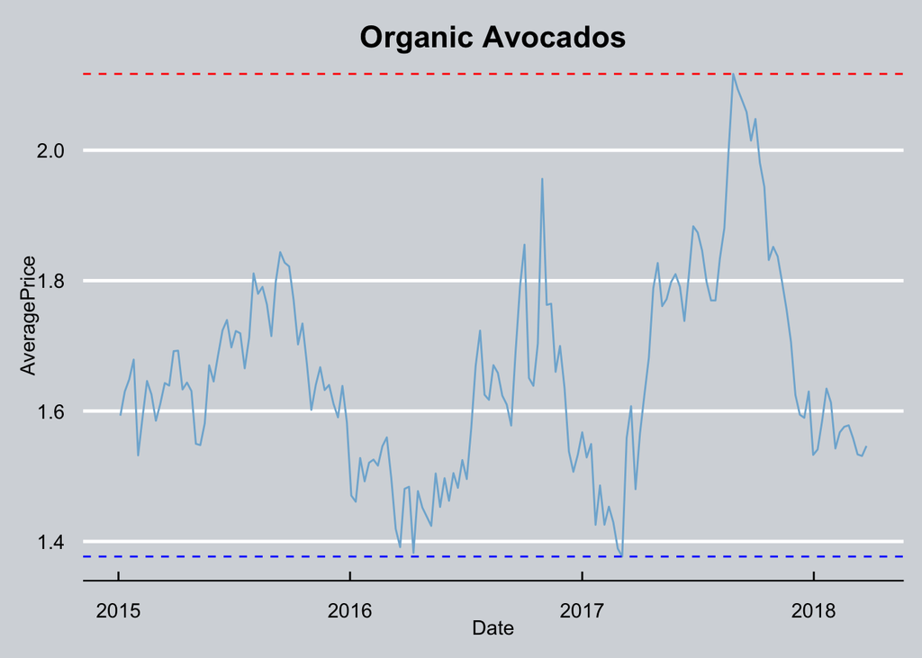

```r
org_monthly <- ggplot(org_month, aes(x = Date, y = AveragePrice)) +
  geom_line(color = "#7FB3D5") +
  theme_economist() +
  theme(
    plot.title = element_text(hjust = 0.5),
    plot.background = element_rect(fill = "#D5D8DC")
  ) +
  labs(title = "Organic Avocados") +
  geom_hline(yintercept = max(org_month$AveragePrice), linetype = "dashed", color = "red") +
  geom_hline(yintercept = min(org_month$AveragePrice), linetype = "dashed", color = "blue")

# Print the plot
print(org_monthly)
```

the week trend plot

Type of patterns: - Cyclical:Fluctuations do not happen on a fixed frequency, - Seasonal: Fluctuations do happen on a fixed frequency. - Trends: This occurs when there is a consistent increase or decrease in our data.

#### Analyzing Seasonal Patterns:

In this section we will try to find if there are any significant reocurring seasonal patterns. By this I mean if there any repeating trends in which the avocado price tend to increase. For instance, in May of each year we see that avocado prices tend to increase for some specific reason.

Distributions per year: It looks that most of the prices in the year of 2015 were in the $1.00 for conventional avocados. While for 2016 and 2017 the density of the prices were a little bit higher.

```r
s_df <- avocado
s_df$month_year <- format(as.Date(avocado$Date), "%Y-%m")
s_df$month <- format(as.Date(avocado$Date), "%m")
s_df$year <- format(as.Date(avocado$Date), "%Y")

s_df$monthabb <- sapply(s_df$month, function(x) month.abb[as.numeric(x)])
s_df$monthabb = factor(s_df$monthabb, levels = month.abb)
```

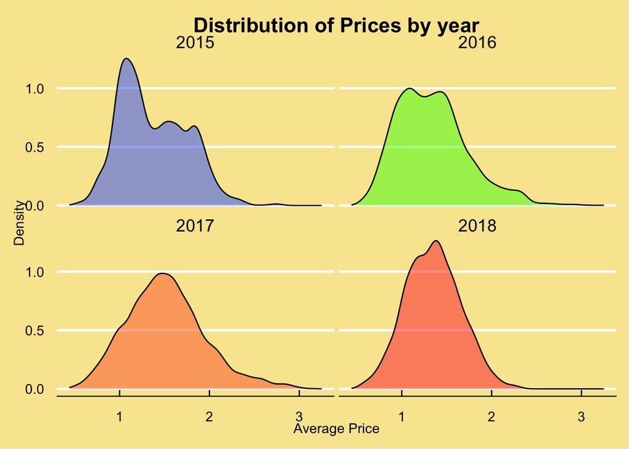

```r
# # Let's see if there are seasonal patterns with conventional avocadoes
ggplot(s_df, aes(x = AveragePrice, fill = as.factor(year))) +
  geom_density(alpha = .5) +
  theme_economist() +
  facet_wrap(~ year) + theme(plot.title=element_text(hjust=0.5), plot.background=element_rect(fill="#F9E79F")) +
  guides(fill = FALSE) + labs(title="Distribution of Prices by year", x = 'Average Price', y = 'Density') +
  scale_fill_manual(values=c("#2E64FE", "#40FF00", "#FE642E", "#FE2E2E"))
```

Price peaks per Month: It looks that most price peaks occur for both conventional and organic avocados between the months of September and October. Interesting enough we see that at the end of the year there is a major price drop in the price of avocados.

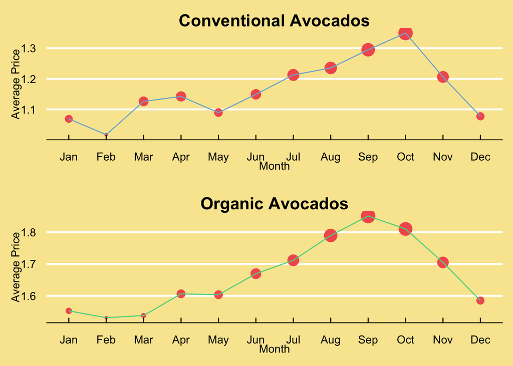

```r
library(cowplot)
# Detecting seasonality patterns
con_patterns <- s_df %>%
  select(monthabb, AveragePrice, type) %>%
  filter(type == "conventional") %>%
  group_by(monthabb) %>%
  summarize(avg=mean(AveragePrice)) %>%
ggplot(aes(x=monthabb, y=avg)) + geom_point(color="#F35D5D", aes(size=avg)) + geom_line(group=1, color="#7FB3D5") +
theme_economist() + theme(legend.position="none", plot.title=element_text(hjust=0.5), plot.background=element_rect(fill="#F9E79F")) +
labs(title="Conventional Avocados", x="Month", y="Average Price")

org_patterns <- s_df %>%
  select(monthabb, AveragePrice, type) %>%
  filter(type == "organic") %>%
  group_by(monthabb) %>%
  summarize(avg=mean(AveragePrice)) %>%
ggplot(aes(x=monthabb, y=avg)) + geom_point(color="#F35D5D", aes(size=avg)) + geom_line(group=1, color="#58D68D") +
theme_economist() + theme(legend.position="none", plot.title=element_text(hjust=0.5), plot.background=element_rect(fill="#F9E79F")) +
labs(title="Organic Avocados", x="Month", y="Average Price")

plot_grid(con_patterns, org_patterns, nrow=2)
```

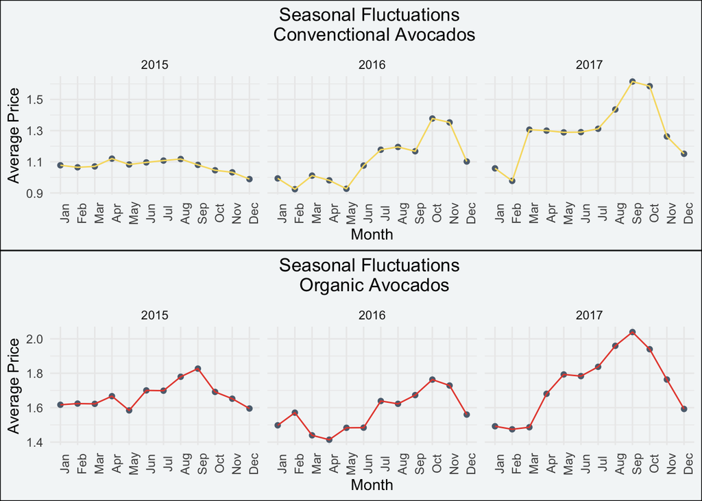

```r
# let's see if the Seasonality pattern is maintained each year.
options(repr.plot.width=8, repr.plot.height=6)
con_pat_yearly <- s_df %>% select(year, monthabb, AveragePrice, type) %>% filter(type == "conventional", year == c("2015", "2016", "2017")) %>%
group_by(year, monthabb) %>% summarize(avg=mean(AveragePrice)) %>%
ggplot(aes(x=monthabb, y=avg)) + geom_point(color="#5D6D7E") + geom_line(group=1, color="#F7DC6F") + facet_wrap(~as.factor(year)) +
theme_minimal() + theme(plot.title=element_text(hjust=0.5), plot.background=element_rect(fill="#F4F6F7"), axis.text.x = element_text(angle = 90)) +
labs(title="Seasonal Fluctuations \n Convenctional Avocados", x="Month", y="Average Price")
org_pat_yearly <- s_df %>% select(year, monthabb, AveragePrice, type) %>% filter(type == "organic", year == c("2015", "2016", "2017")) %>%
  group_by(year, monthabb) %>% summarize(avg=mean(AveragePrice)) %>%
ggplot(aes(x=monthabb, y=avg)) + geom_point(color="#5D6D7E") + geom_line(group=1, color="#E74C3C") + facet_wrap(~as.factor(year)) +
theme_minimal() + theme(plot.title=element_text(hjust=0.5), plot.background=element_rect(fill="#F4F6F7"), axis.text.x = element_text(angle = 90)) +
labs(title="Seasonal Fluctuations \n Organic Avocados", x="Month", y="Average Price")
plot_grid(con_pat_yearly, org_pat_yearly, nrow=2)
```

Standard deviation as a measure of volatility: Standard deviation is just the square root of a variance. We can see that during the year of 2017, the avocado market experienced the highest volatility for both conventional and organic avocados.

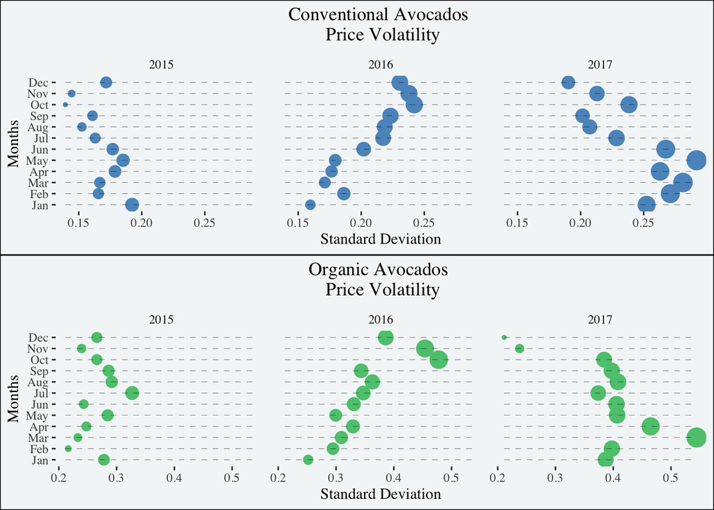

```r
# Measuring standard deviation per month through each year by type of avocado.
std_con <- s_df %>% select(year, monthabb, AveragePrice, type) %>% filter(type == "conventional", year == c("2015", "2016", "2017")) %>%
group_by(year, monthabb) %>% summarize(std=sd(AveragePrice)) %>%
ggplot(aes(x=monthabb, y=std)) +
  geom_point(aes(size=std), col="#5A96C6") +   # Draw points
  geom_segment(aes(x=monthabb,
                   xend=monthabb,
                   y=min(std),
                   yend=max(std)),
               linetype="dashed",
               size=0.1) +
  coord_flip() +
facet_wrap(~year) +
theme_tufte() +
theme(plot.title=element_text(hjust=0.5), plot.background=element_rect(fill="#F4F6F7"), legend.position="none") +
labs(title="Conventional Avocados \n Price Volatility",x="Months", y="Standard Deviation")
std_org <- s_df %>% select(year, monthabb, AveragePrice, type) %>% filter(type == "organic", year == c("2015", "2016", "2017")) %>%
group_by(year, monthabb) %>% summarize(std=sd(AveragePrice)) %>%
ggplot(aes(x=monthabb, y=std)) +
  geom_point(aes(size=std), col="#5AC67C") +   # Draw points
  geom_segment(aes(x=monthabb,
                   xend=monthabb,
                   y=min(std),
                   yend=max(std)),
               linetype="dashed",
               size=0.1) +
  coord_flip() +
facet_wrap(~year) +
theme_tufte() +
theme(plot.title=element_text(hjust=0.5), plot.background=element_rect(fill="#F4F6F7"), legend.position="none") +
labs(title="Organic Avocados \n Price Volatility",x="Months", y="Standard Deviation")
plot_grid(std_con, std_org, nrow=2)
```

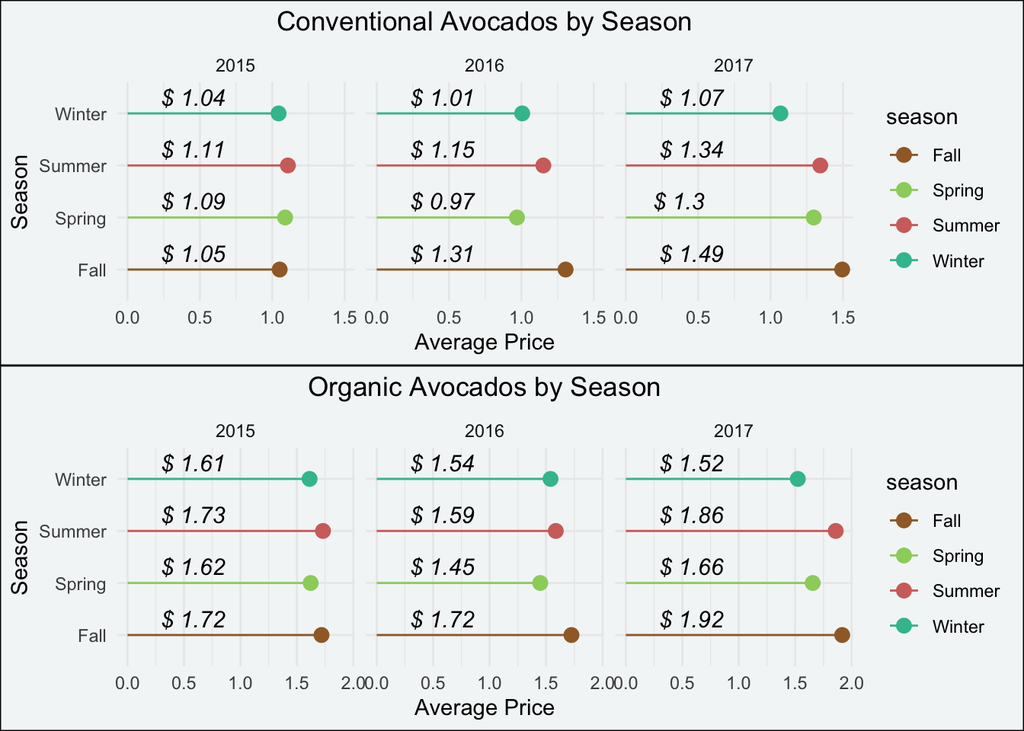

```r
options(repr.plot.width=8, repr.plot.height=6)

# Let's create a seasonal column and plot a point line chart by each year.
s_df$season <- ifelse(s_df$month %in% c("03", "04","05"), "Spring", ifelse(s_df$month %in% c("06","07" ,"08"), "Summer", ifelse(s_df$month %in% c("09","10","11"), "Fall", "Winter")))

seasonality.plot.conventional <- s_df %>% select(season, year, AveragePrice, type) %>%
filter(type == "conventional", year == c("2015", "2016", "2017")) %>%
group_by(season, year) %>%
summarize(avg=mean(AveragePrice)) %>% ggplot(aes(x=season, y=avg, color=season)) + geom_point(size=3) +
 geom_segment(aes(x=season,
                   xend=season,
                   y=0,
                   yend=avg)) +
coord_flip() + facet_wrap(~as.factor(year)) + theme_minimal() +
theme(plot.title=element_text(hjust=0.5), plot.background=element_rect(fill="#F4F6F7")) +
scale_color_manual(values=c("#a06a31", "#9bd16b", "#d1706b", "#3bbf9e")) +
labs(title="Conventional Avocados by Season", x="Season", y="Average Price") +
geom_text(aes(x=season, y=0.01, label= paste0("$ ", round(avg,2))),
            hjust=-0.5, vjust=-0.5, size=4,
            colour="black", fontface="italic",
         angle=360)
seasonality.plot.organic <- s_df %>% select(season, year, AveragePrice, type) %>%
filter(type == "organic", year == c("2015", "2016", "2017")) %>%
group_by(season, year) %>%
summarize(avg=mean(AveragePrice)) %>% ggplot(aes(x=season, y=avg, color=season)) + geom_point(size=3) +
 geom_segment(aes(x=season,
                   xend=season,
                   y=0,
                   yend=avg)) +
coord_flip() + facet_wrap(~as.factor(year)) + theme_minimal() +
theme(plot.title=element_text(hjust=0.5), plot.background=element_rect(fill="#F4F6F7")) +
scale_color_manual(values=c("#a06a31", "#9bd16b", "#d1706b", "#3bbf9e")) +
labs(title="Organic Avocados by Season", x="Season", y="Average Price") +
geom_text(aes(x=season, y=0.01, label= paste0("$ ", round(avg,2))),
            hjust=-0.5, vjust=-0.5, size=4,
            colour="black", fontface="italic",
         angle=360)
plot_grid(seasonality.plot.conventional, seasonality.plot.organic, nrow=2)
```

```r
library(forecast)
```

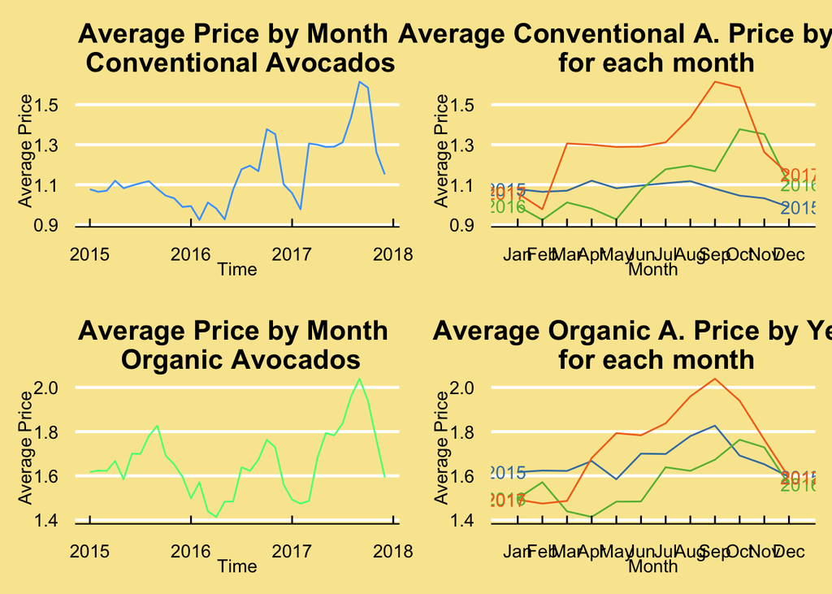

```r
options(repr.plot.width=10, repr.plot.height=8)

con.price <- s_df %>% select(type,year, monthabb, AveragePrice) %>% filter(type == "conventional", year == c("2015", "2016", "2017")) %>%
group_by(year, monthabb) %>% summarize(avg=mean(AveragePrice))
org.price <- s_df %>% select(type,year, monthabb, AveragePrice) %>% filter(type == "organic", year == c("2015", "2016", "2017")) %>%
group_by(year, monthabb) %>% summarize(avg=mean(AveragePrice))
con.price <- ts(con.price$avg, start=2015, frequency=12)
org.price <- ts(org.price$avg, start=2015, frequency=12)

con.plot <- autoplot(con.price, color="#48a4ff") +
theme_economist() + theme(plot.title=element_text(hjust=0.5), plot.background=element_rect(fill="#F9E79F")) +
labs(title="Average Price by Month \n Conventional Avocados", y="Average Price")

org.plot <- autoplot(org.price, color="#58FA82") +
theme_economist() + theme(plot.title=element_text(hjust=0.5), plot.background=element_rect(fill="#F9E79F")) +
labs(title="Average Price by Month \n Organic Avocados", y="Average Price")

byyear.plot.con <- ggseasonplot(con.price, year.labels=TRUE, year.labels.left=TRUE) + theme_economist() +
theme(plot.title=element_text(hjust=0.5), plot.background=element_rect(fill="#F9E79F")) +
labs(title="Average Conventional A. Price by Year \n for each month", y="Average Price") +
scale_color_manual(values=c("#407EAF","#68B842", "#F1711E"))


byyear.plot.org <- ggseasonplot(org.price, year.labels=TRUE, year.labels.left=TRUE) + theme_economist() +
theme(plot.title=element_text(hjust=0.5), plot.background=element_rect(fill="#F9E79F")) +
labs(title="Average Organic A. Price by Year \n for each month", y="Average Price") +
scale_color_manual(values=c("#407EAF","#68B842", "#F1711E"))


plot_grid(con.plot, byyear.plot.con, org.plot, byyear.plot.org, nrow=2, ncol=2)
```

- Analyzing the “smooth” component: Perform a trend and seasonality analysis, choosing from the methods given in Sections 1.3 and 1.4 of the Lecture Notes. After this step, the resulting residuals should pass as stationary time series.

Small trend method: STEP 1: Compute yearly average $\hat m_j$ over all months a $\hat m_j=\frac{1}{12}\sum_{k=1}^{12}x_{j,k}$ and eliminate the yearly trend (The trend within each period is constant)

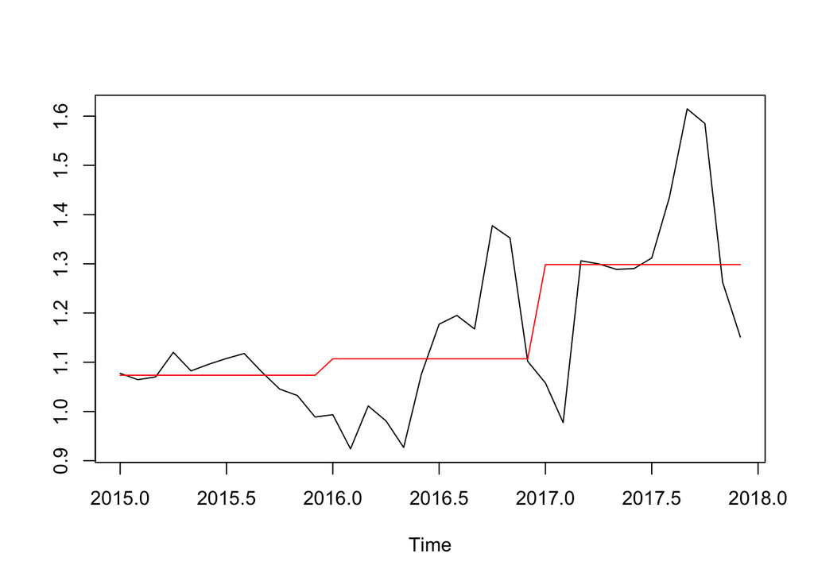

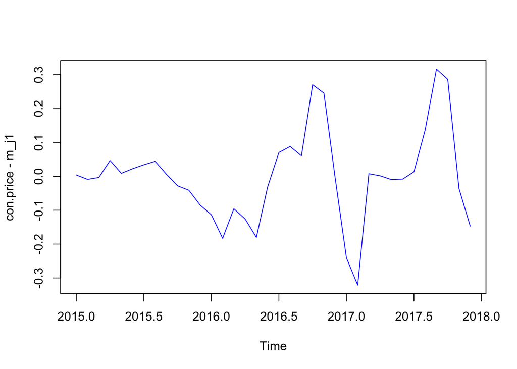

STEP 2: Compute monthly average $\hat s_k$ Seasonal component is constant for the same month across years.

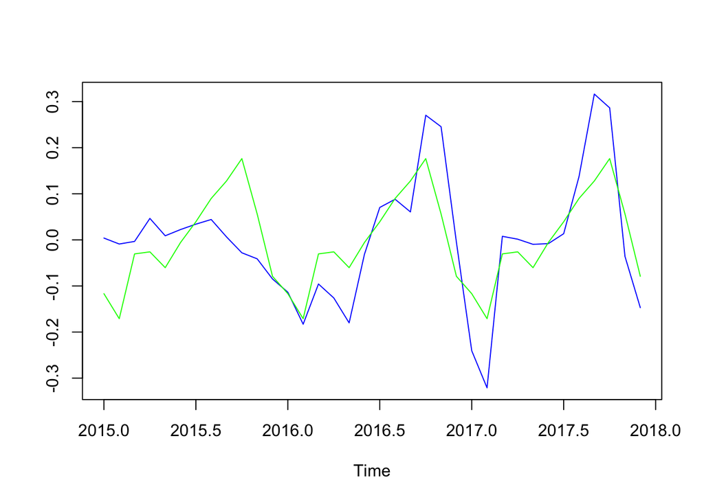

```r
res1=con.price-m_j1-s_k1
adf.test(res1)
```

```
##
##  Augmented Dickey-Fuller Test
##
## data:  res1
## Dickey-Fuller = -3.1086, Lag order = 3, p-value = 0.1418
## alternative hypothesis: stationary
```

- Analyzing the residuals: Check the residuals for whiteness, remaining trends and normality as outlined in Section 1.5 of the Lecture Notes. Hopefully your residuals display some stationary time series features.

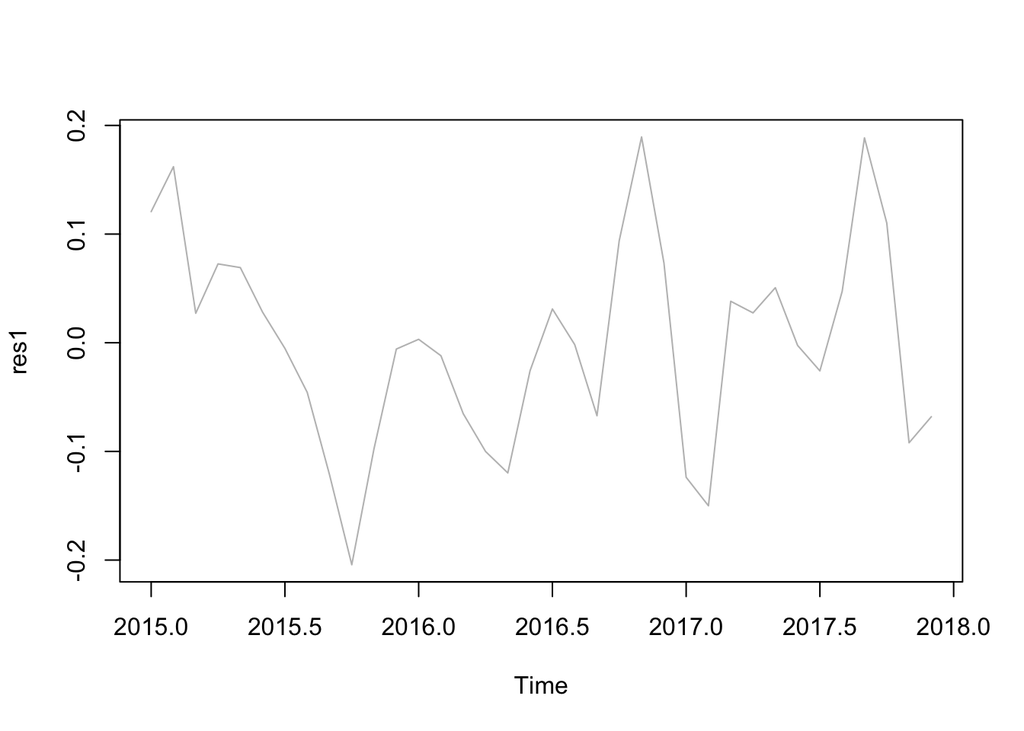

```r
ts.plot(res1,col="grey")
```

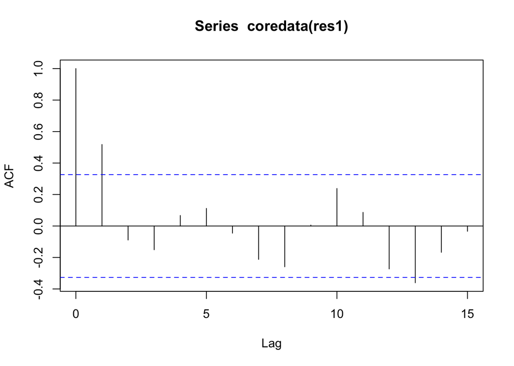

```r
acf(coredata(res1))
```

It has lag 1, so it is not a whiteness.

```r
# Perform Ljung-Box test for autocorrelation
Box.test(res1, lag = 20, type = "Ljung-Box")
```

```
##
##  Box-Ljung test
##
## data:  res1
## X-squared = 35.566, df = 20, p-value = 0.01729
```

Remaining Trernds

```r
t=1:length(con.price)
```

```r
# Plot residuals over time
res_fit=lm(res1~t)
summary(res_fit)
```

```
##
## Call:
## lm(formula = res1 ~ t)
##
## Residuals:
##       Min        1Q    Median        3Q       Max
## -0.204320 -0.067376 -0.002071  0.055273  0.189346
##
## Coefficients:
##               Estimate Std. Error t value Pr(>|t|)
## (Intercept)  1.893e-17  3.260e-02       0        1
## t           -1.204e-18  1.537e-03       0        1
##
## Residual standard error: 0.09577 on 34 degrees of freedom
## Multiple R-squared:  3.401e-32,  Adjusted R-squared:  -0.02941
## F-statistic: 1.156e-30 on 1 and 34 DF,  p-value: 1
```

Therefore, there is no remaining trend.

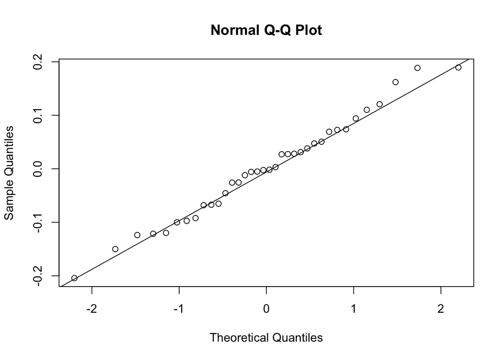

```r
# Q-Q plot of residuals
qqnorm(res1)
qqline(res1)
```

Therefore, it follows normal distribution.

```r
# Shapiro-Wilk test for normality
shapiro.test(res1)
```

```
##
##  Shapiro-Wilk normality test
##
## data:  res1
## W = 0.98541, p-value = 0.9064
```

- Analyzing the “rough” component: Fit stationary ARMA models to the residuals obtained after the analysis of the smooth component, as outlined in Chapter 3 (see Section 3.6 for a summary) of the Lecture Notes. Make sure to provide ACF and PACF plots for support. Check if the residuals conform to white noise. If not, there is still dependence left in the data that could be utilized for improved modeling.

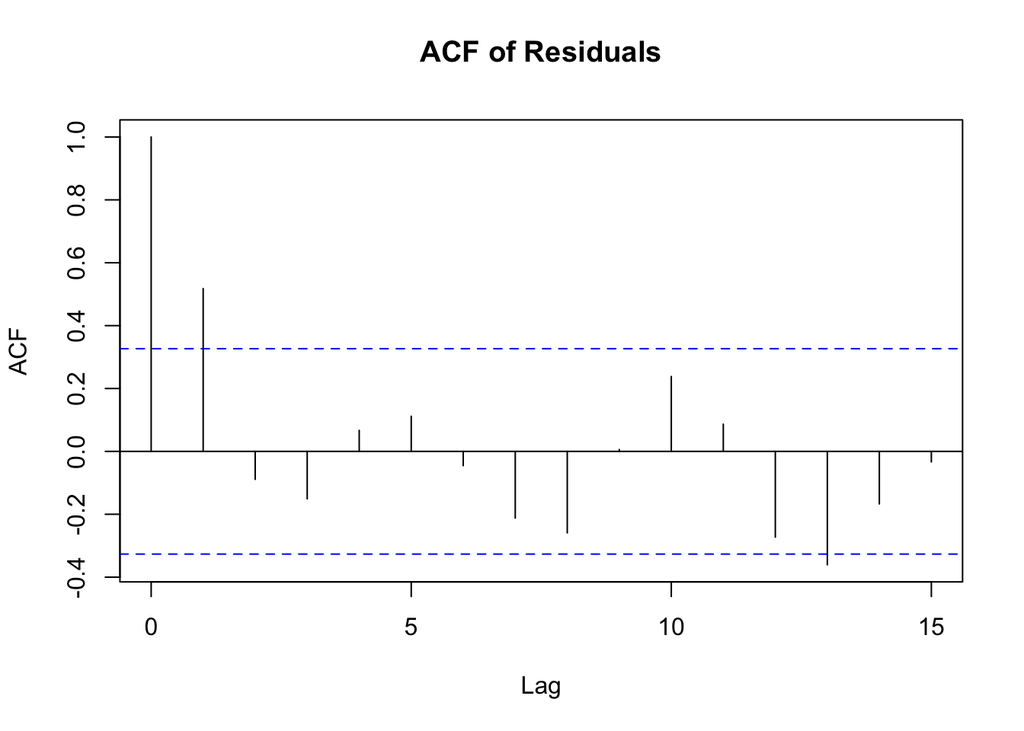

```r
acf(coredata(res1), main="ACF of Residuals")
```

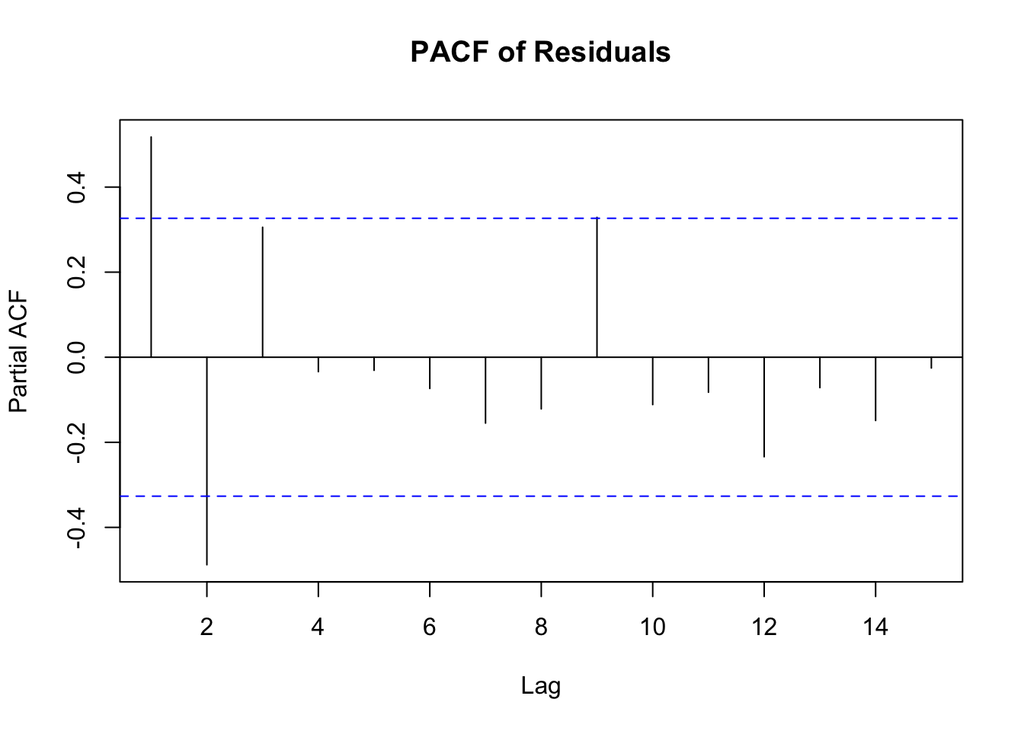

```r
pacf(coredata(res1), main="PACF of Residuals")
```

ARMA(2,1)

```r
arma_model=arima(res1,c(2,0,1))
print(arma_model)
```

```
##
## Call:
## arima(x = res1, order = c(2, 0, 1))
##
## Coefficients:
##          ar1      ar2     ma1  intercept
##       0.4897  -0.3762  0.4080    -0.0003
## s.e.  0.2433   0.2011  0.2393     0.0175
##
## sigma^2 estimated as 0.004374:  log likelihood = 46.15,  aic = -82.31
```

```r
# Assuming 'arma_model' is the residuals of the fitted ARMA model
# Load necessary library
library(randtests)
# Runs test
runs.test(arma_model$residuals)
```

```
##
##  Runs Test
##
## data:  arma_model$residuals
## statistic = 0, runs = 19, n1 = 18, n2 = 18, n = 36, p-value = 1
## alternative hypothesis: nonrandomness
```

```r
arima_model_cv <- auto.arima(res1, d=1, D=1, stepwise=FALSE, approximation=FALSE, trace=TRUE)
```

```
##
##  ARIMA(0,1,0)(0,1,0)[12]                    : -20.74755
##  ARIMA(0,1,0)(0,1,1)[12]                    : -20.2403
##  ARIMA(0,1,0)(1,1,0)[12]                    : -20.2403
##  ARIMA(0,1,0)(1,1,1)[12]                    : -17.57714
##  ARIMA(0,1,1)(0,1,0)[12]                    : -20.10896
##  ARIMA(0,1,1)(0,1,1)[12]                    : -18.62019
##  ARIMA(0,1,1)(1,1,0)[12]                    : -18.62019
##  ARIMA(0,1,1)(1,1,1)[12]                    : -15.66112
##  ARIMA(0,1,2)(0,1,0)[12]                    : Inf
##  ARIMA(0,1,2)(0,1,1)[12]                    : -22.15632
##  ARIMA(0,1,2)(1,1,0)[12]                    : -22.15413
##  ARIMA(0,1,2)(1,1,1)[12]                    : Inf
##  ARIMA(0,1,3)(0,1,0)[12]                    : Inf
##  ARIMA(0,1,3)(0,1,1)[12]                    : Inf
##  ARIMA(0,1,3)(1,1,0)[12]                    : Inf
##  ARIMA(0,1,3)(1,1,1)[12]                    : Inf
##  ARIMA(0,1,4)(0,1,0)[12]                    : Inf
##  ARIMA(0,1,4)(0,1,1)[12]                    : -18.3933
##  ARIMA(0,1,4)(1,1,0)[12]                    : -18.26764
##  ARIMA(0,1,5)(0,1,0)[12]                    : -18.51577
##  ARIMA(1,1,0)(0,1,0)[12]                    : -18.58537
##  ARIMA(1,1,0)(0,1,1)[12]                    : -17.81824
##  ARIMA(1,1,0)(1,1,0)[12]                    : -17.81748
##  ARIMA(1,1,0)(1,1,1)[12]                    : Inf
##  ARIMA(1,1,1)(0,1,0)[12]                    : -19.21145
##  ARIMA(1,1,1)(0,1,1)[12]                    : -17.15779
##  ARIMA(1,1,1)(1,1,0)[12]                    : -17.18638
##  ARIMA(1,1,1)(1,1,1)[12]                    : Inf
##  ARIMA(1,1,2)(0,1,0)[12]                    : Inf
##  ARIMA(1,1,2)(0,1,1)[12]                    : Inf
##  ARIMA(1,1,2)(1,1,0)[12]                    : Inf
##  ARIMA(1,1,2)(1,1,1)[12]                    : Inf
##  ARIMA(1,1,3)(0,1,0)[12]                    : Inf
##  ARIMA(1,1,3)(0,1,1)[12]                    : Inf
##  ARIMA(1,1,3)(1,1,0)[12]                    : Inf
##  ARIMA(1,1,4)(0,1,0)[12]                    : Inf
##  ARIMA(2,1,0)(0,1,0)[12]                    : -25.88782
##  ARIMA(2,1,0)(0,1,1)[12]                    : -23.27584
##  ARIMA(2,1,0)(1,1,0)[12]                    : -23.22069
```

[output cut: 11 more lines]

```
##  ARIMA(3,1,0)(1,1,0)[12]                    : -20.76628
##  ARIMA(3,1,0)(1,1,1)[12]                    : Inf
##  ARIMA(3,1,1)(0,1,0)[12]                    : -20.2951
##  ARIMA(3,1,1)(0,1,1)[12]                    : Inf
##  ARIMA(3,1,1)(1,1,0)[12]                    : Inf
##  ARIMA(3,1,2)(0,1,0)[12]                    : -16.6026
##  ARIMA(4,1,0)(0,1,0)[12]                    : -20.27896
##  ARIMA(4,1,0)(0,1,1)[12]                    : -17.14495
##  ARIMA(4,1,0)(1,1,0)[12]                    : Inf
##  ARIMA(4,1,1)(0,1,0)[12]                    : -16.5825
##  ARIMA(5,1,0)(0,1,0)[12]                    : -16.89049
##
##
##
##  Best model: ARIMA(2,1,0)(0,1,0)[12]
```

```r
print(summary(arima_model_cv))
```

```
## Series: res1
## ARIMA(2,1,0)(0,1,0)[12]
##
## Coefficients:
##          ar1      ar2
##       0.2384  -0.6456
## s.e.  0.1696   0.1690
##
## sigma^2 = 0.01446:  log likelihood = 16.58
## AIC=-27.15   AICc=-25.89   BIC=-23.74
##
## Training set error measures:
##                      ME       RMSE        MAE      MPE    MAPE     MASE
## Training set 0.00241735 0.09185654 0.06229424 66.63347 371.294 0.484015
##                    ACF1
## Training set -0.1019061
```

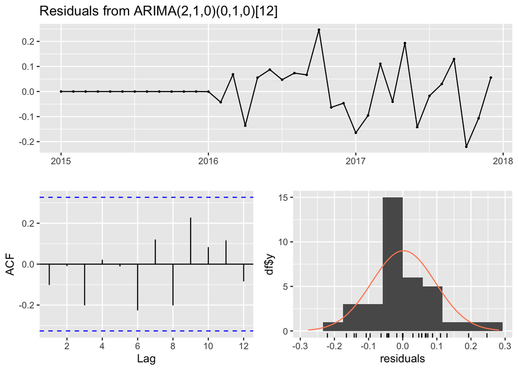

```
##
##  Ljung-Box test
##
## data:  Residuals from ARIMA(2,1,0)(0,1,0)[12]
## Q* = 5.1341, df = 5, p-value = 0.3997
##
## Model df: 2.   Total lags used: 7
```

```r
checkresiduals(arima_model_cv) + theme_minimal()
```

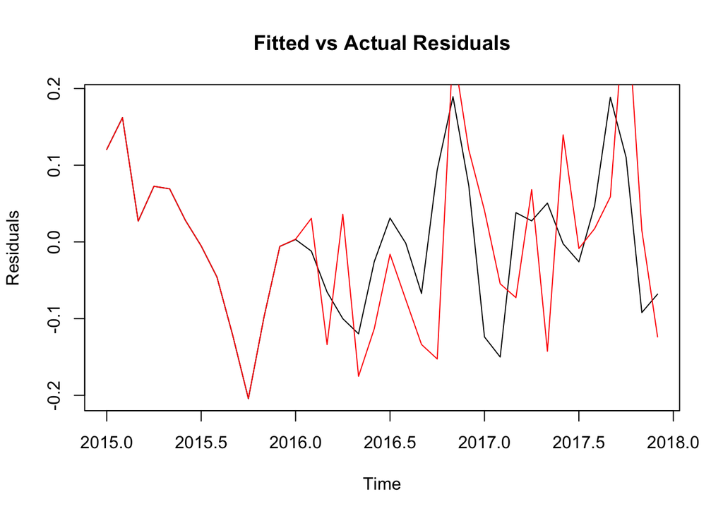

```r
# Plot the fitted values against the actual residuals
plot(res1, main="Fitted vs Actual Residuals", ylab="Residuals")
lines(fitted(arima_model_cv), col="red")
```

- Predict future values: The prediction of the time series is given by the prediction of the smooth component plus the prediction of the rough component. For the smooth part, you need to make sure to be able to predict trend and seasonality. For the rough part, use one of the algorithms in Section 3.5 of the Lecture Notes.

### Trend Components $X_t=m_t+Y_t$

least squares estimation

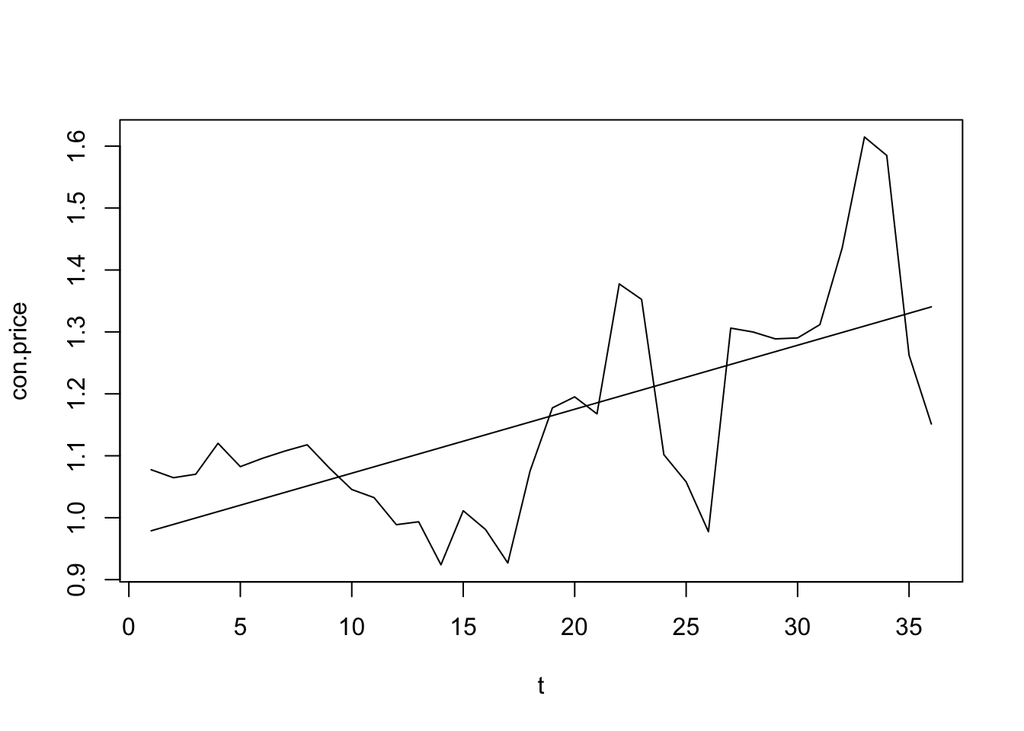

```r
t=1:length(con.price)
confit=lm(con.price~t)
plot(t,con.price,"line")
lines(confit$fit)
```

```r
summary(confit)
```

```
##
## Call:
## lm(formula = con.price ~ t)
##
## Residuals:
##      Min       1Q   Median       3Q      Max
## -0.25979 -0.10519  0.01922  0.06774  0.30526
##
## Coefficients:
##             Estimate Std. Error t value Pr(>|t|)
## (Intercept) 0.968567   0.045000  21.524  < 2e-16 ***
## t           0.010330   0.002121   4.871 2.53e-05 ***
## ---
## Signif. codes:  0 '***' 0.001 '**' 0.01 '*' 0.05 '.' 0.1 ' ' 1
##
## Residual standard error: 0.1322 on 34 degrees of freedom
## Multiple R-squared:  0.411,  Adjusted R-squared:  0.3936
## F-statistic: 23.72 on 1 and 34 DF,  p-value: 2.527e-05
```

```r
trend_res=confit$residuals
```

$X_t=0.968567+0.010330*t$

```r
seasonal_componet=con.price-trend_res
```

```r
# Fit linear regression model for seasonality
seasonal_model <- lm(seasonal_componet ~ sin(2 * pi * t / 12) + cos(2 * pi * t / 12), data =con.price)
summary(seasonal_model)
```

```
##
## Call:
## lm(formula = seasonal_componet ~ sin(2 * pi * t/12) + cos(2 *
##     pi * t/12), data = con.price)
##
## Residuals:
##     Min      1Q  Median      3Q     Max
## -0.1704 -0.1112  0.0000  0.1112  0.1704
##
## Coefficients:
##                    Estimate Std. Error t value Pr(>|t|)
## (Intercept)         1.15967    0.01802  64.344   <2e-16 ***
## sin(2 * pi * t/12) -0.03855    0.02549  -1.513    0.140
## cos(2 * pi * t/12)  0.01033    0.02549   0.405    0.688
## ---
## Signif. codes:  0 '***' 0.001 '**' 0.01 '*' 0.05 '.' 0.1 ' ' 1
##
## Residual standard error: 0.1081 on 33 degrees of freedom
## Multiple R-squared:  0.06917,    Adjusted R-squared:  0.01275
## F-statistic: 1.226 on 2 and 33 DF,  p-value: 0.3065
```

```r
arma_forecast_residual=seasonal_model$residuals
forcast_arma_model= auto.arima(res1, d=1, D=1, stepwise=FALSE, approximation=FALSE, trace=TRUE)
```

```
##
##  ARIMA(0,1,0)(0,1,0)[12]                    : -20.74755
##  ARIMA(0,1,0)(0,1,1)[12]                    : -20.2403
##  ARIMA(0,1,0)(1,1,0)[12]                    : -20.2403
##  ARIMA(0,1,0)(1,1,1)[12]                    : -17.57714
##  ARIMA(0,1,1)(0,1,0)[12]                    : -20.10896
##  ARIMA(0,1,1)(0,1,1)[12]                    : -18.62019
##  ARIMA(0,1,1)(1,1,0)[12]                    : -18.62019
##  ARIMA(0,1,1)(1,1,1)[12]                    : -15.66112
##  ARIMA(0,1,2)(0,1,0)[12]                    : Inf
##  ARIMA(0,1,2)(0,1,1)[12]                    : -22.15632
##  ARIMA(0,1,2)(1,1,0)[12]                    : -22.15413
##  ARIMA(0,1,2)(1,1,1)[12]                    : Inf
##  ARIMA(0,1,3)(0,1,0)[12]                    : Inf
##  ARIMA(0,1,3)(0,1,1)[12]                    : Inf
##  ARIMA(0,1,3)(1,1,0)[12]                    : Inf
##  ARIMA(0,1,3)(1,1,1)[12]                    : Inf
##  ARIMA(0,1,4)(0,1,0)[12]                    : Inf
##  ARIMA(0,1,4)(0,1,1)[12]                    : -18.3933
##  ARIMA(0,1,4)(1,1,0)[12]                    : -18.26764
##  ARIMA(0,1,5)(0,1,0)[12]                    : -18.51577
##  ARIMA(1,1,0)(0,1,0)[12]                    : -18.58537
##  ARIMA(1,1,0)(0,1,1)[12]                    : -17.81824
##  ARIMA(1,1,0)(1,1,0)[12]                    : -17.81748
##  ARIMA(1,1,0)(1,1,1)[12]                    : Inf
##  ARIMA(1,1,1)(0,1,0)[12]                    : -19.21145
##  ARIMA(1,1,1)(0,1,1)[12]                    : -17.15779
##  ARIMA(1,1,1)(1,1,0)[12]                    : -17.18638
##  ARIMA(1,1,1)(1,1,1)[12]                    : Inf
##  ARIMA(1,1,2)(0,1,0)[12]                    : Inf
##  ARIMA(1,1,2)(0,1,1)[12]                    : Inf
##  ARIMA(1,1,2)(1,1,0)[12]                    : Inf
##  ARIMA(1,1,2)(1,1,1)[12]                    : Inf
##  ARIMA(1,1,3)(0,1,0)[12]                    : Inf
##  ARIMA(1,1,3)(0,1,1)[12]                    : Inf
##  ARIMA(1,1,3)(1,1,0)[12]                    : Inf
##  ARIMA(1,1,4)(0,1,0)[12]                    : Inf
##  ARIMA(2,1,0)(0,1,0)[12]                    : -25.88782
##  ARIMA(2,1,0)(0,1,1)[12]                    : -23.27584
##  ARIMA(2,1,0)(1,1,0)[12]                    : -23.22069
```

[output cut: 11 more lines]

```
##  ARIMA(3,1,0)(1,1,0)[12]                    : -20.76628
##  ARIMA(3,1,0)(1,1,1)[12]                    : Inf
##  ARIMA(3,1,1)(0,1,0)[12]                    : -20.2951
##  ARIMA(3,1,1)(0,1,1)[12]                    : Inf
##  ARIMA(3,1,1)(1,1,0)[12]                    : Inf
##  ARIMA(3,1,2)(0,1,0)[12]                    : -16.6026
##  ARIMA(4,1,0)(0,1,0)[12]                    : -20.27896
##  ARIMA(4,1,0)(0,1,1)[12]                    : -17.14495
##  ARIMA(4,1,0)(1,1,0)[12]                    : Inf
##  ARIMA(4,1,1)(0,1,0)[12]                    : -16.5825
##  ARIMA(5,1,0)(0,1,0)[12]                    : -16.89049
##
##
##
##  Best model: ARIMA(2,1,0)(0,1,0)[12]
```

```r
print(summary(forcast_arma_model))
```

```
## Series: res1
## ARIMA(2,1,0)(0,1,0)[12]
##
## Coefficients:
##          ar1      ar2
##       0.2384  -0.6456
## s.e.  0.1696   0.1690
##
## sigma^2 = 0.01446:  log likelihood = 16.58
## AIC=-27.15   AICc=-25.89   BIC=-23.74
##
## Training set error measures:
##                      ME       RMSE        MAE      MPE    MAPE     MASE
## Training set 0.00241735 0.09185654 0.06229424 66.63347 371.294 0.484015
##                    ACF1
## Training set -0.1019061
```

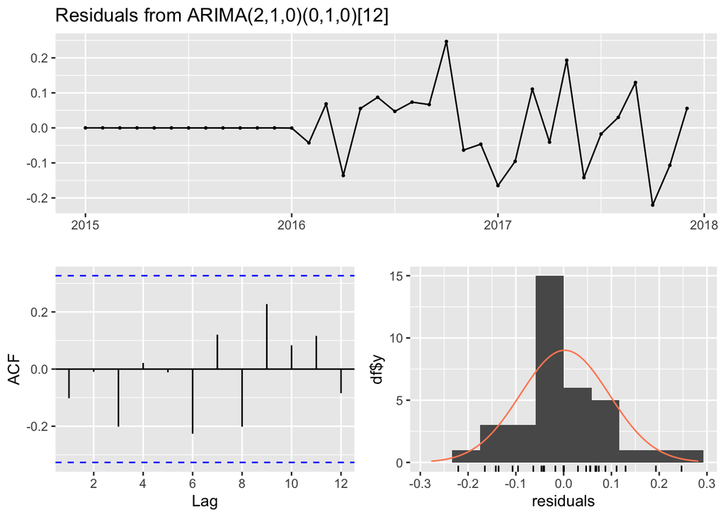

```
##
##  Ljung-Box test
##
## data:  Residuals from ARIMA(2,1,0)(0,1,0)[12]
## Q* = 5.1341, df = 5, p-value = 0.3997
##
## Model df: 2.   Total lags used: 7
```

```r
checkresiduals(forcast_arma_model) + theme_minimal()
```

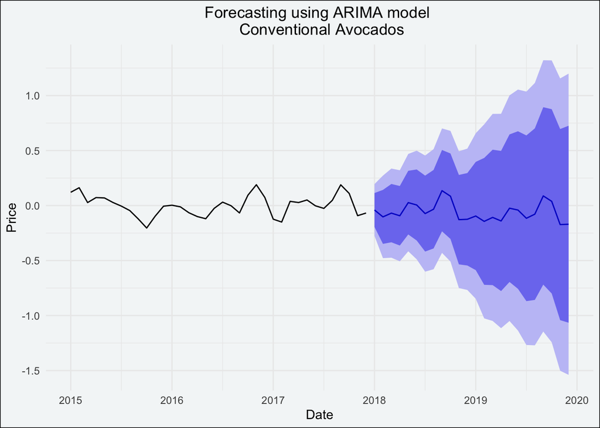

```r
forecast_model <- forecast(forcast_arma_model, h=24)
# Include means including the last 60 months in order to see closer the forecast.
autoplot(forecast_model, include=60) + theme_minimal() + theme(plot.title=element_text(hjust=0.5), plot.background=element_rect(fill="#F4F6F7"),
      legend.position="bottom", legend.background = element_rect(fill="#FFF9F5",
                                  size=0.5, linetype="solid",
                                  colour ="black")) +
labs(title="Forecasting using ARIMA model \n Conventional Avocados", x="Date", y="Price")
```

### rough component

```r
summary(forecast_model)
```

```
##
## Forecast method: ARIMA(2,1,0)(0,1,0)[12]
##
## Model Information:
## Series: res1
## ARIMA(2,1,0)(0,1,0)[12]
##
## Coefficients:
##          ar1      ar2
##       0.2384  -0.6456
## s.e.  0.1696   0.1690
##
## sigma^2 = 0.01446:  log likelihood = 16.58
## AIC=-27.15   AICc=-25.89   BIC=-23.74
##
## Error measures:
##                      ME       RMSE        MAE      MPE    MAPE     MASE
## Training set 0.00241735 0.09185654 0.06229424 66.63347 371.294 0.484015
##                    ACF1
## Training set -0.1019061
##
## Forecasts:
##          Point Forecast      Lo 80     Hi 80      Lo 95     Hi 95
## Jan 2018   -0.040398069 -0.1945283 0.1137321 -0.2761199 0.1953237
## Feb 2018   -0.103006386 -0.3483416 0.1423289 -0.4782143 0.2722015
## Mar 2018   -0.068904958 -0.3338874 0.1960775 -0.4741606 0.3363507
## Apr 2018   -0.092861534 -0.3634464 0.1777233 -0.5066854 0.3209623
## May 2018    0.026634832 -0.2627297 0.3159994 -0.4159101 0.4691797
## Jun 2018    0.005069102 -0.3177966 0.3279348 -0.4887114 0.4988496
## Jul 2018   -0.073038628 -0.4182105 0.2721332 -0.6009334 0.4548562
## Aug 2018   -0.033222037 -0.3901307 0.3236866 -0.5790667 0.5126227
## Sep 2018    0.135317679 -0.2345281 0.5051635 -0.4303126 0.7009480
## Oct 2018    0.085046086 -0.3033638 0.4734560 -0.5089756 0.6790678
## Nov 2018   -0.128150100 -0.5346206 0.2783204 -0.7497931 0.4934929
## Dec 2018   -0.124865460 -0.5449554 0.2952245 -0.7673376 0.5176067
## Jan 2019   -0.095089129 -0.5871418 0.3969636 -0.8476188 0.6574405
## Feb 2019   -0.143804349 -0.7205387 0.4329300 -1.0258434 0.7382347
## Mar 2019   -0.107765652 -0.7231255 0.5075942 -1.0488773 0.8333460
## Apr 2019   -0.140229494 -0.7773780 0.4969190 -1.1146641 0.8342051
## May 2019   -0.024011931 -0.6945990 0.6465751 -1.0495863 1.0015624
## Jun 2019   -0.040867206 -0.7570525 0.6753181 -1.1361781 1.0544437
## Jul 2019   -0.115735227 -0.8689339 0.6374634 -1.2676532 1.0361827
## Aug 2019   -0.078187265 -0.8578778 0.7015033 -1.2706211 1.1142466
## Sep 2019    0.087720114 -0.7186601 0.8941003 -1.1455320 1.3209722
## Oct 2019    0.038285553 -0.7994947 0.8760658 -1.2429887 1.3195598
## Nov 2019   -0.173011699 -1.0416849 0.6956615 -1.5015327 1.1555093
## Dec 2019   -0.169814722 -1.0650153 0.7253859 -1.5389059 1.1992764
```

ARIMA Model Specification:

ARIMA(2,1,0)(0,1,0)[12]: This represents an ARIMA model with two autoregressive (AR) terms, one differencing (I) term of order 1, and no moving average (MA) terms. The seasonal component involves a seasonal differencing of order 1 and a seasonal period of 12.